# US Birth Statistics

Harald groven

10/14/2018

[Description of assignement](https://docs.google.com/document/d/e/2PACX-1vQq5ozMyz6qoCpNOJNUOPQbyDQyNtVWcPEvJppYxp30YlOkHhUslTplCac8OJH80AN2PZnDtiUWl62W/pub)

# Download data frin cdc.gov

Since this is slow, I have commented out bash commands after runnding these first time.

```bash
# Download zip file to working directory

# curl -O ftp://ftp.cdc.gov/pub/Health_Statistics/NCHS/Datasets/DVS/natality/Nat2017us.zip
# unzip Nat2017us.zip
```

Census microdata for all 2017 births in the US is concained. Each row reprsents one birth. Fixed file format, i.e. relative position of each variable are always the same for each line.

In a sane world, the data would be provided in a format where the codebook is in another format than PDF. The most efficient way of solving this exercise would have been to download the data as a STATA, SAS or SPSS files from [National Bureau of Economic Research](http://www.nber.org/data/vital-statistics-natality-data.html), and convert the data to R.

The fixed format datafile has the name Nat2017PublicUS.c20180516.r20180808.txt when unzipped. The R function read_fwf is able to parse this file format.

| Variable name | Position in fwf file |
| --- | --- |
| dob_mm | From position 13 to position 14 |
| sex | From position 475 to position 475 |
| dbwt | From position 504 to position 507 |

# What is the proportion of boys to girls?

| sex | n_births | freq |
| --- | --- | --- |
| F | 1887091 | 48.82823 |
| M | 1977663 | 51.17177 |

# What is the average birth weight in grams?

Calculating mean value on variable dbwt gives the following result:

[output not shown]

# Make a density plot on the birth weight between boys and girls. Is it different?

First filter out unknown values, which is coded as 9999. A density plot (of type geom_density) yield the following result.

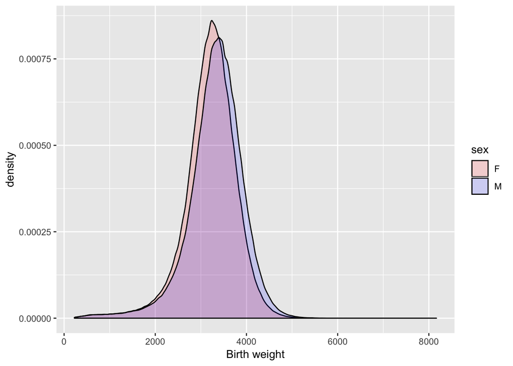

# Does the average birth weight vary by month?

Birth weight seems pretty consistent for all months between 3250 and 3270 gram. However, birth weight is sligtly lower in December and January.

| dob_mm | mean_birth_weight |
| --- | --- |
| 1 | 3252.256 |
| 2 | 3260.639 |
| 3 | 3262.990 |
| 4 | 3266.531 |
| 5 | 3267.867 |
| 6 | 3264.266 |
| 7 | 3263.729 |
| 8 | 3265.932 |
| 9 | 3268.226 |
| 10 | 3261.624 |
| 11 | 3259.406 |
| 12 | 3251.082 |

```
## No summary function supplied, defaulting to `mean_se()
```

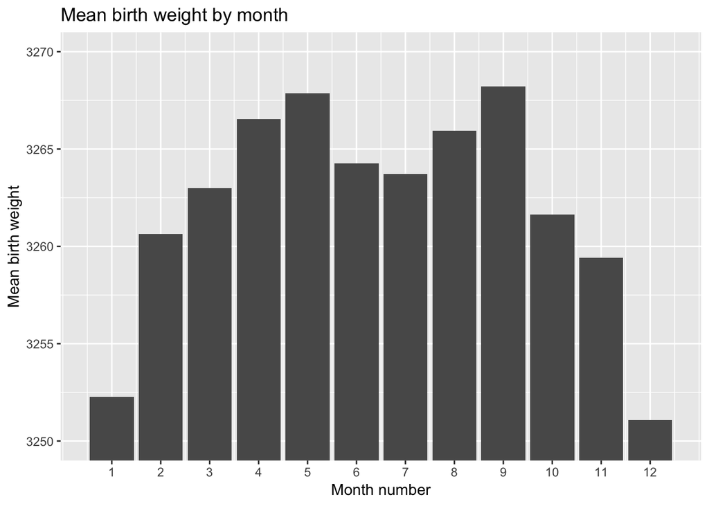